# Workshop 18 [Week 8]: Model evaluation and violations

## 3. Linearity

No reason for stats here. Are there any reasons to be concerned about linearity problems for categorical predictors (see lecture if needed)?

Let’s have a look anyway. Because we have categorical predicts, we need `tukeyboxplot` instead of `scatterplot`. Fill in the **xxx**s. We want the residuals of `model_2` on the y-axis and `age_2` on the x-axis.

```r
#tukeyboxplot(data = data, y = xxx, x = xxx)
```

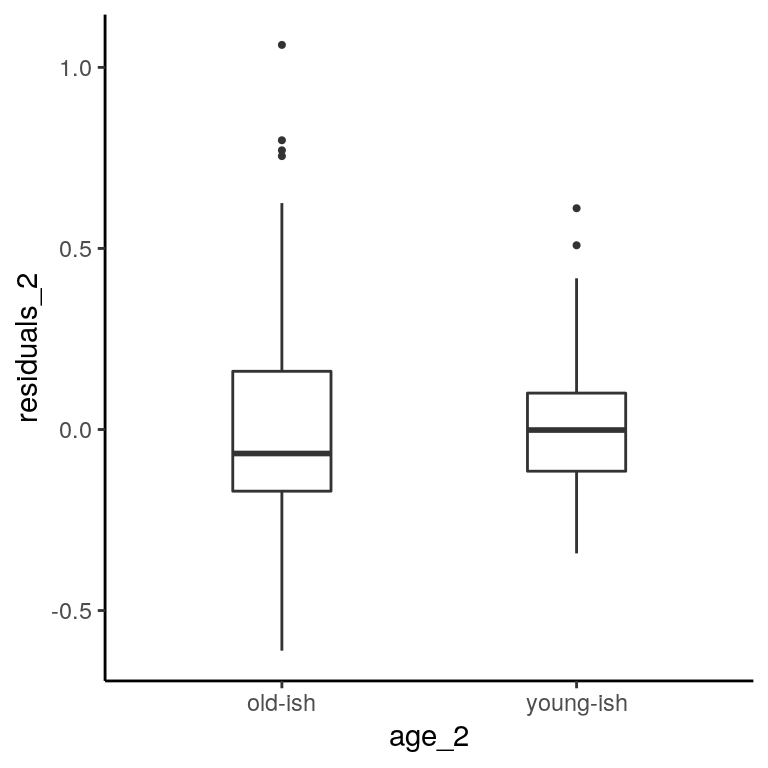

```r
tukeyboxplot(data = data, y = residuals_2, x = age_2) # answer
```

Repeat of the residuals of `model_3` and `age_3`.

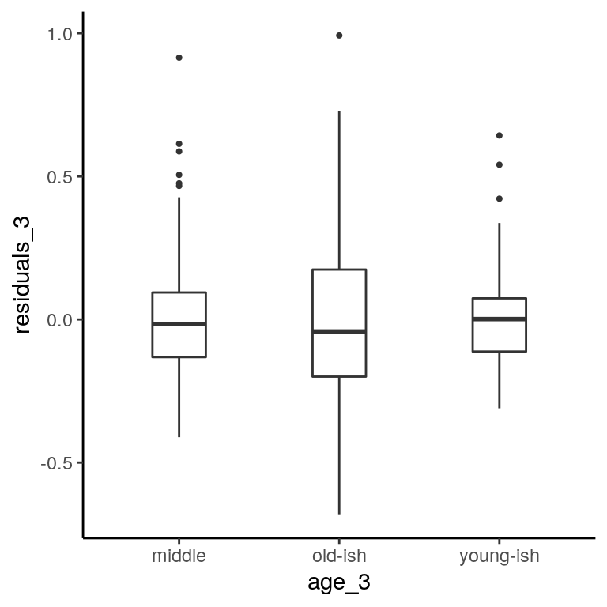

```r
tukeyboxplot(data = data, y = residuals_3, x = age_3) # answer
```

Do you have any concerns that linearity might be violated?

**Answer:** No reason to worry at all. As we learned in the lecture, for categorical predictors there is no reason to assume anything but a linear relationship (imagine a horizontal line between the boxes from your boxplots).

## 4. Independence

We tested independence above on the basis of participant ids using scatterplots. Create a scatterplot with `residuals_2` on the y and `id` on the x-axis; add a line of best fit.

```r
#scatterplot(data = data, y = xxx, x = xxx, best_fit_line = xxx)
```

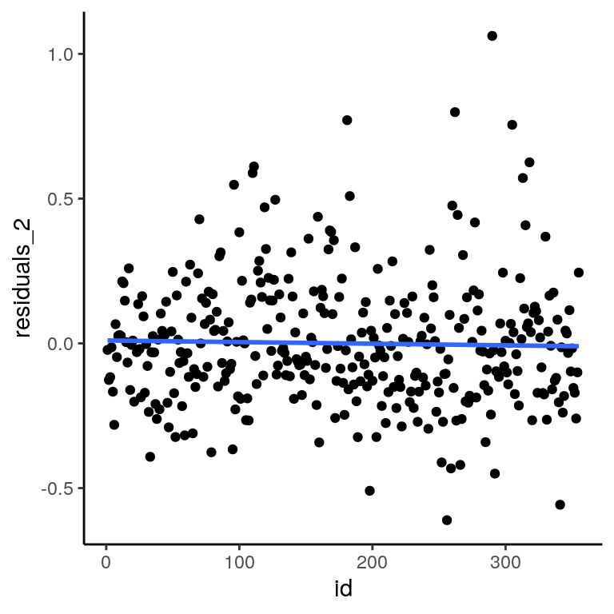

```r
scatterplot(data = data, y =residuals_2, x = id, best_fit_line = T) # answer
```

Is there any reason to be concerned about independence problems?

**Answer:** Not a lot. If anything when you observe that participants between 100 and 150 have positive residuals and there is larger variability for later participants (around 300).

### Bonus

First, extract predicted data. Replace the **xxx**s correctly. We want to extract the predicted rts from `model_2` and store them in `predict_2`.

```r
#data <- mutate(data, xxx = predict(xxx))
```

```r
data <- mutate(data, predict_2 = predict(model_2)) # answer
```

Repeat for `model_3` and save the predicted rts in `predict_3`.

```r
data <- mutate(data, predict_3 = predict(model_3)) # answer
```

```r
#scatterplot(data = data, y = residuals_2, x = predict_2)
```

## 5. Normality

We can assess normality in histograms. Create a histogram for `model_2` with `residuals_2` on the x-axis and 20 bins.

```r
#histogram(data = data, x = xxx, bins = xxx)
```

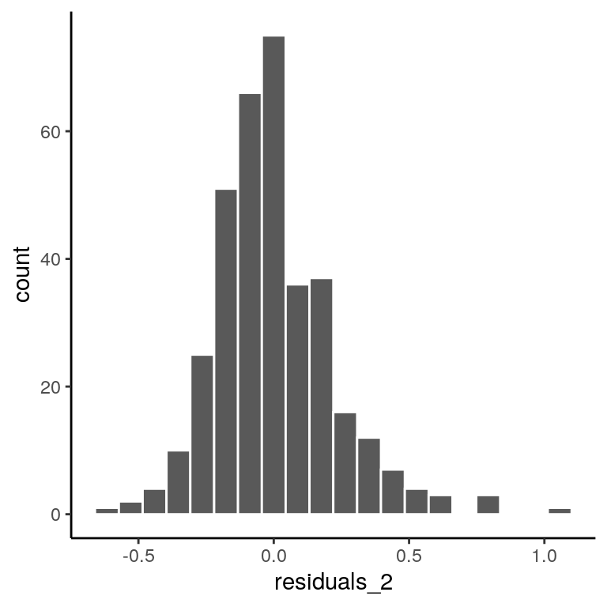

```r
histogram(data = data, x = residuals_2, bins = 20) # answer
```

Repeat for the residuals of `model_3`.

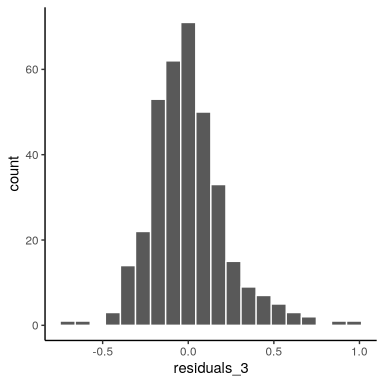

```r
histogram(data = data, x = residuals_3, bins = 20) # answer
```

Now, lets also calculate the skewness of the residuals. For the residuals of `model_2` replace the **xxx**s with `residuals_2`.

```r
#library(moments)
#describe(data = data, skew = skewness(xxx))
```

```r
library(moments)
describe(data = data, skew = skewness(residuals_2)) # answer
```

```
# A tibble: 1 x 1
   skew
  <dbl>
1 0.908
```

Repeat for the residuals of `model_3`.

```r
#describe(data = data, skew = skewness(xxx))
```

```r
describe(data = data, skew = skewness(residuals_3)) # answer
```

```
# A tibble: 1 x 1
   skew
  <dbl>
1 0.866
```

Repeat for kurtosis:

```r
#describe(data = data, kurt = kurtosis(xxx))
```

```r
describe(data = data, kurt = kurtosis(residuals_2)) # answer
```

```
# A tibble: 1 x 1
   kurt
  <dbl>
1  5.26
```

```r
describe(data = data, kurt = kurtosis(residuals_3)) # answer
```

```
# A tibble: 1 x 1
   kurt
  <dbl>
1  5.42
```

Do we need to be concerned about normality?

**Answer:** Not a lot. The tails are a little wide and there seem to be some issues with kurtosis (*k* > 3). Skewness seems to be fine though (-2 $<$ skew $<$ 2).

## 6. Equality of variance

We’ve had a look at this earlier (without knowing). The boxplots for the residuals of `model_2` (in particular the whiskers of the boxes) show us the variance for each group. We see that the variability in the old group is larger than the variability in the young group.

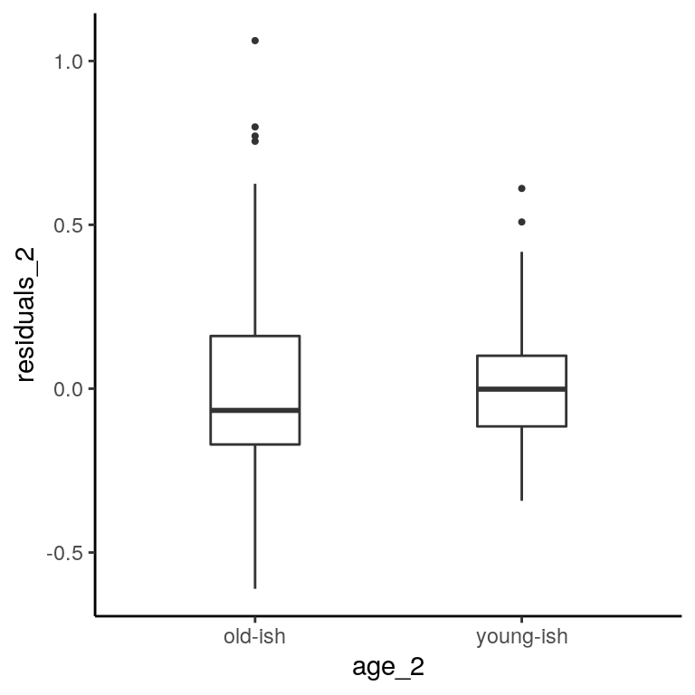

```r
tukeyboxplot(data = data, x = age_2, y = residuals_2)
```

Repeat the boxplot for the residuals of `model_3`. Does any of the three groups show a larger variability?

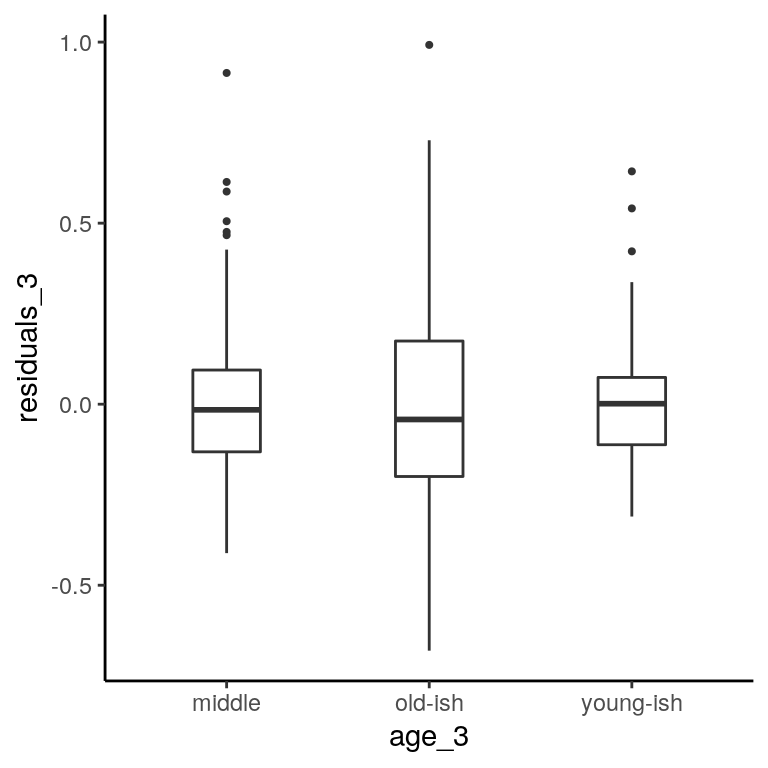

```r
tukeyboxplot(data = data, x = age_3, y = residuals_3) # answer
```

**Answer:** The variability in the old group is larger than in the other two groups.

# Summary

Well done. You just achieved a whole lot!

- You fitted 3 models, 1 with a continuous and 2 with a categorical predictor.
- You extracted the residuals of all of them,
- scrutinised the residuals with regards to *LINE* linearity, independence, normality, equality (of variance),
- and you used a log transformation to correct for a violation of normality.

# References

Baayen, R. H. (2008). *Analyzing linguistic data. A practical introduction to statistics using R*. Cambridge University Press.

Baayen, R. H., Davidson, D. J., & Bates, D. M. (2008). Mixed-effects modeling with crossed random effects for subjects and items. *Journal of Memory and Language*, *59*(4), 390–412.

Blomkvist, A. W., Eika, F., Rahbek, M. T., Eikhof, K. D., Hansen, M. D., Søndergaard, M., Ryg, J., Andersen, S., & Jørgensen, M. G. (2017). Reference data on reaction time and aging using the Nintendo Wii Balance Board: A cross-sectional study of 354 subjects from 20 to 99 years of age. *PLoS One*, *12*(12), e0189598. https://journals.plos.org/plosone/article?id=10.1371/journal.pone.0189598

Faraway, J. J. (2015). *Linear models with R* (Vol. 2). CRC press.

Fox, J., & Weisberg, S. (2018). *An R companion to applied regression* (Vol. 3). Sage publications.